# University Mental Health IoT Dataset Analysis

## Overview

This notebook explores a comprehensive dataset of university mental health data collected through IoT sensors. The dataset contains 1000 observations with 15-minute intervals over 11 days (May 1-11, 2024), capturing various environmental and physiological factors that may influence student stress levels.

## Dataset Description

The dataset includes the following key variables:

- **Environmental factors**: Air quality index, noise levels, lighting, temperature, humidity, crowd density
- **Physiological factors**: Sleep hours, mood score, mental health status
- **Temporal factors**: Timestamp data for temporal pattern analysis
- **Target variable**: Stress level (our primary outcome of interest)

## Exploration Steps Done

1. **Feature Engineering**: Created temporal features to capture time-based patterns
2. **Correlation Analysis**: Identify which factors most strongly correlate with stress levels
3. **Feature Importance**: Use XGBoost to determine feature importance rankings related to predicting stress
4. **Daily Analysis**: Examine correlation and feature importance by day

## Data Loading and Initial Setup

We begin by loading the dataset and setting up our analysis environment. The dataset is stored as a CSV file containing IoT sensor data from university environments.

```python
import pandas as pd
import numpy as np
import xgboost as xgb
import matplotlib.pyplot as plt
```

```python
# Load the university mental health IoT dataset
# This dataset contains 1000 observations with environmental and physiological data
data = pd.read_csv('../data/university_mental_health_iot_dataset.csv')
```

## Feature Engineering: Temporal Analysis

### Rationale

Temporal patterns might be helpful here. Students may experience different stress levels at different times of day, days of the week, or during specific periods.

### Features Created

1. **Day of Month**: Captures potential weekly patterns or end-of-month stress
2. **Hour of Day**: Identifies peak stress hours (e.g., early morning vs. late night)
3. **Time Buckets**: Groups hours into meaningful periods (4-hour and 6-hour buckets)
4. **15-minute Increments**: Since the data comes in 15 minutes, can use this as the most granular time variable

```python
# Convert timestamp column to datetime format for temporal analysis
# This enables extraction of various time-based features
data['timestamp'] = pd.to_datetime(data['timestamp'])
```

```python
data['timestamp_day'] = pd.to_datetime(data['timestamp'].dt.date)
```

```python
data[['timestamp_day']].drop_duplicates() # where it is verified that all timestamp are May 1-10
```

|  | timestamp_day |
| --- | --- |
| 0 | 2024-05-01 |
| 64 | 2024-05-02 |
| 160 | 2024-05-03 |
| 256 | 2024-05-04 |
| 352 | 2024-05-05 |
| 448 | 2024-05-06 |
| 544 | 2024-05-07 |
| 640 | 2024-05-08 |
| 736 | 2024-05-09 |
| 832 | 2024-05-10 |
| 928 | 2024-05-11 |

```python
data['timestamp_day_of_week'] = data['timestamp'].apply(lambda x: x.isoweekday()) # get day of week as ISO weekday (1=Monday, 7=Sunday). Future work: Make it a categorical variable
data['timestamp_day_of_month'] = data['timestamp'].dt.day
data.drop(['timestamp_day'], axis=1, inplace=True)
```

```python
data['timestamp_hour'] = data['timestamp'].dt.hour
data['timestamp_hour_4_hour_bucket'] = data['timestamp'].dt.hour // 4
data['timestamp_hour_6_hour_bucket'] = data['timestamp'].dt.hour // 6
```

```python
# get an integer for number of 15-minute increments since the epoch
num_15_min_incs = data['timestamp'].astype(np.int64) // 10**9 / (60*15)
```

```python
# ensure that indeed, there are only 15 minute increments
assert set(num_15_min_incs.apply(lambda x: x.is_integer())) == {True}
```

```python
# now that it is verified, make the feature
data['timestamp_num_15_min_incs'] = (num_15_min_incs - np.min(num_15_min_incs)).astype(np.int64)

# that feature will be exactly in step with timestamp so the timestamp column can be dropped now
data = data.drop(['timestamp'], axis=1)
```

## Correlation Analysis

### Approach

We calculate Pearson correlation coefficients, the default one in Pandas, between all features and stress levels. This gives us a baseline understanding of linear relationships in the data.

### Interpretation Guidelines

- **Strong correlations (|r| > 0.5)**: Indicate strong linear relationships
- **Moderate correlations (0.3 < |r| < 0.5)**: Suggest meaningful relationships
- **Weak correlations (|r| < 0.3)**: May still be important in combination with other factors

### Limitations

Correlation analysis only captures linear relationships. Non-linear relationships (e.g., U-shaped or threshold effects) may be missed. This is why XGBoost was also tried

```python
# Calculate correlation coefficients between all features and stress level
# Sort by absolute correlation to identify strongest relationships

def get_features_most_corr_with_stress(input_data):
    out_df = input_data.corr()['stress_level'].reset_index().rename(
        columns={'index': 'Feature',
                 'stress_level': 'Correlation'})

    out_df = out_df[out_df['Feature'] != 'stress_level'] # leave out redundant feature

    out_df['Correlation_Ranking'] = np.abs(out_df['Correlation']).rank(method='first', ascending=False).astype(int)
    out_df = out_df.sort_values(by='Correlation_Ranking')
    return out_df
```

```python
feats_and_corrs_df = get_features_most_corr_with_stress(data)
```

```python
feats_and_corrs_df
```

|  | Feature | Correlation | Correlation_Ranking |
| --- | --- | --- | --- |
| 10 | mental_health_status | 0.825346 | 1 |
| 3 | air_quality_index | 0.561575 | 2 |
| 8 | sleep_hours | -0.443454 | 3 |
| 9 | mood_score | -0.408509 | 4 |
| 4 | noise_level_db | 0.246461 | 5 |
| 6 | crowd_density | 0.210913 | 6 |
| 1 | temperature_celsius | -0.048635 | 7 |
| 13 | timestamp_hour | 0.048259 | 8 |
| 14 | timestamp_hour_4_hour_bucket | 0.046579 | 9 |
| 11 | timestamp_day_of_week | 0.036475 | 10 |
| 15 | timestamp_hour_6_hour_bucket | 0.035773 | 11 |
| 12 | timestamp_day_of_month | -0.032834 | 12 |
| 16 | timestamp_num_15_min_incs | -0.028488 | 13 |
| 0 | location_id | 0.017891 | 14 |
| 2 | humidity_percent | -0.012519 | 15 |
| 5 | lighting_lux | 0.009530 | 16 |

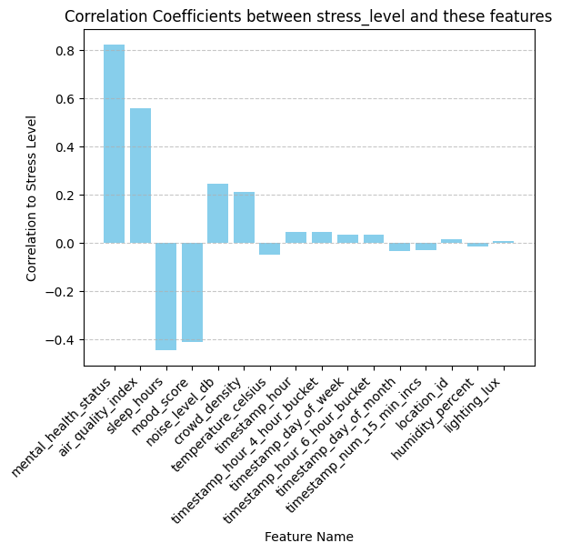

```python
fig, ax = plt.subplots()

ax.bar(feats_and_corrs_df['Feature'], feats_and_corrs_df['Correlation'], color='skyblue')
ax.set_title('Correlation Coefficients between stress_level and these features')
ax.set_xlabel('Feature Name')
ax.set_ylabel('Correlation to Stress Level')
ax.grid(axis='y', linestyle='--', alpha=0.7)
plt.xticks(rotation=45, ha='right')
plt.show()
```

The top features most correlated are:

- mental_health_status
- air_quality_index
- sleep_hours
- mood_score
- noise_level_db
- crowd_density
- The above ran a simple correlation. As a secondary test, we will do a basic XGBoost model. I won't do any train/test split or cross validation, just train a decision tree and see what emerges as the most important features

## XGBoost Feature Importance Analysis

### Why XGBoost?

XGBoost is particularly well-suited for this analysis because:

1. **Non-linear relationships**: Can capture complex interactions between features
2. **Feature importance**: Provides clear rankings of feature importance
3. **Robustness**: Handles different data types and scales well
4. **Interpretability**: Feature importance scores are easy to understand

### Model Configuration

We use a conservative configuration to avoid overfitting:

- **Shallow trees (max_depth=2)**: Focus on main effects rather than complex interactions
- **Small number of trees (n_estimators=20)**: Prevents overfitting on limited data
- **Regularization**: L1 and L2 regularization to encourage sparsity and smoothness

### Feature Importance Interpretation

Higher importance scores indicate features that contribute more to predicting stress levels. This helps identify the most actionable factors for intervention strategies.

```python
feature_data = data.drop('stress_level', axis=1)
```

```python
target_data = data['stress_level']
```

```python
# parameters suggested by Gemini for training an XGBoost model
#   that is meant to show correlations
XGB_PARAMS = {
    'objective': 'reg:squarederror',  # Standard for regression
    'n_estimators': 20,               # Small number of trees (e.g., 10 to 50)
    'max_depth': 2,                   # Very shallow trees (depth 1 or 2). Depth 1 is a "decision stump".
    'learning_rate': 0.3,             # Relatively high learning rate
    'subsample': 0.7,                 # Helps prevent overfitting on small data by using a subset of samples per tree
    'colsample_bytree': 0.7,          # Helps prevent overfitting and encourages diversity by using a subset of features per tree
    'gamma': 0.1,                     # Minimum loss reduction required to make a split. Small non-zero value can prune minor splits.
    'reg_alpha': 0.1,                 # L1 regularization on weights. Encourages sparsity.
    'reg_lambda': 1,                  # L2 regularization on weights. Smoother.
    'random_state': 42                # For reproducibility
}
```

```python
# Function to train XGBoost model and extract feature importance scores
# Returns sorted DataFrame of features by importance
def train_and_get_importances(feature_data, target_data):

    xgb_model = xgb.XGBRegressor(**XGB_PARAMS)
    xgb_model.fit(feature_data, target_data)
    out_df = pd.DataFrame({
        'Feature': feature_data.columns,
        'Importance': xgb_model.feature_importances_
    }).sort_values(by='Importance', ascending=False)

    # Fix: Use 'first' method to ensure unique rankings and handle ties properly
    out_df['Importance_Ranking'] = out_df['Importance'].rank(ascending=False, method='first').astype(int)
    return out_df
```

## Iterative Feature Analysis

### Strategy

We perform multiple XGBoost analyses, progressively removing the most dominant features to understand the relative importance of different factor groups.

### Analysis Phases

1. **Full Model**: All features included
2. **Without Mental Health Status**: Removes the most dominant feature to see secondary factors
3. **Environmental Focus**: Removes mental health, sleep, and mood to focus on environmental factors

### Benefits

This approach helps us understand:

- Which factors are most important overall
- What environmental factors matter when controlling for mental health status
- How different factor groups interact and contribute to stress prediction

### Practical Implications

Understanding the hierarchy of factors helps universities prioritize intervention strategies. For example, if environmental factors remain important even after controlling for mental health status, this suggests that improving the physical environment could benefit all students.

```python
importances_df = train_and_get_importances(feature_data, target_data)
```

```python
importances_df
```

|  | Feature | Importance | Importance_Ranking |
| --- | --- | --- | --- |
| 9 | mental_health_status | 0.573544 | 1 |
| 7 | sleep_hours | 0.107805 | 2 |
| 8 | mood_score | 0.096048 | 3 |
| 3 | air_quality_index | 0.095237 | 4 |
| 4 | noise_level_db | 0.041096 | 5 |
| 6 | crowd_density | 0.025362 | 6 |
| 2 | humidity_percent | 0.014134 | 7 |
| 13 | timestamp_hour_4_hour_bucket | 0.013503 | 8 |
| 1 | temperature_celsius | 0.012135 | 9 |
| 5 | lighting_lux | 0.010908 | 10 |
| 10 | timestamp_day_of_week | 0.010228 | 11 |
| 0 | location_id | 0.000000 | 12 |
| 11 | timestamp_day_of_month | 0.000000 | 13 |
| 12 | timestamp_hour | 0.000000 | 14 |
| 14 | timestamp_hour_6_hour_bucket | 0.000000 | 15 |
| 15 | timestamp_num_15_min_incs | 0.000000 | 16 |

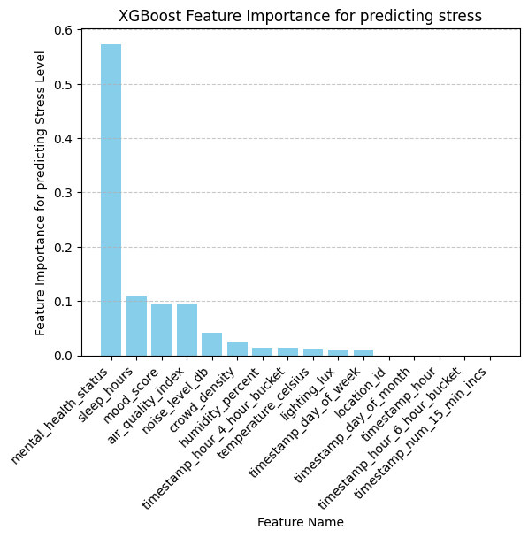

```python
fig2, ax = plt.subplots()

ax.bar(importances_df['Feature'], importances_df['Importance'], color='skyblue')
ax.set_title('XGBoost Feature Importance for predicting stress')
ax.set_xlabel('Feature Name')
ax.set_ylabel('Feature Importance for predicting Stress Level')
ax.grid(axis='y', linestyle='--', alpha=0.7)
plt.xticks(rotation=45, ha='right')
plt.show()
```

Mental health status is quite dominant. Will likely be useful to see what happens when that is left out

```python
importances_df_2 = train_and_get_importances(feature_data.drop('mental_health_status', axis=1), target_data)
importances_df_2
```

|  | Feature | Importance | Importance_Ranking |
| --- | --- | --- | --- |
| 3 | air_quality_index | 0.360679 | 1 |
| 7 | sleep_hours | 0.183843 | 2 |
| 8 | mood_score | 0.142098 | 3 |
| 4 | noise_level_db | 0.077426 | 4 |
| 6 | crowd_density | 0.058172 | 5 |
| 5 | lighting_lux | 0.039088 | 6 |
| 1 | temperature_celsius | 0.033736 | 7 |
| 2 | humidity_percent | 0.030084 | 8 |
| 11 | timestamp_hour | 0.029456 | 9 |
| 14 | timestamp_num_15_min_incs | 0.019736 | 10 |
| 0 | location_id | 0.016940 | 11 |
| 9 | timestamp_day_of_week | 0.008742 | 12 |
| 10 | timestamp_day_of_month | 0.000000 | 13 |
| 12 | timestamp_hour_4_hour_bucket | 0.000000 | 14 |
| 13 | timestamp_hour_6_hour_bucket | 0.000000 | 15 |

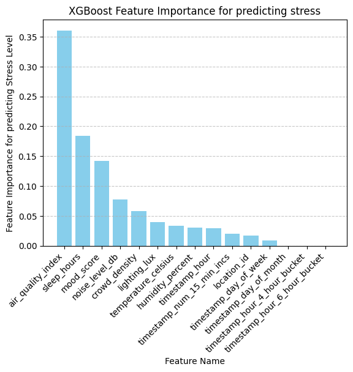

```python
# Note: I am purposefully not putting this into a function so the visualizations can be easier to customize individually later
fig3, ax = plt.subplots()

ax.bar(importances_df_2['Feature'], importances_df_2['Importance'], color='skyblue')
ax.set_title('XGBoost Feature Importance for predicting stress')
ax.set_xlabel('Feature Name')
ax.set_ylabel('Feature Importance for predicting Stress Level')
ax.grid(axis='y', linestyle='--', alpha=0.7)
plt.xticks(rotation=45, ha='right')
plt.show()
```

As a final test, see what happens when air_quality_index, sleep_hours, mood_score is also left out. This way there are only environmental factors and we can see what role they play by themselves

```python
importances_df_3 = train_and_get_importances(feature_data.drop(['mental_health_status', 'air_quality_index', 'sleep_hours', 'mood_score'], axis=1), target_data)
importances_df_3
```

|  | Feature | Importance | Importance_Ranking |
| --- | --- | --- | --- |
| 3 | noise_level_db | 0.224323 | 1 |
| 5 | crowd_density | 0.173783 | 2 |
| 9 | timestamp_hour_4_hour_bucket | 0.128370 | 3 |
| 11 | timestamp_num_15_min_incs | 0.100561 | 4 |
| 1 | temperature_celsius | 0.092571 | 5 |
| 2 | humidity_percent | 0.091206 | 6 |
| 4 | lighting_lux | 0.070049 | 7 |
| 6 | timestamp_day_of_week | 0.069912 | 8 |
| 8 | timestamp_hour | 0.049225 | 9 |
| 0 | location_id | 0.000000 | 10 |
| 7 | timestamp_day_of_month | 0.000000 | 11 |
| 10 | timestamp_hour_6_hour_bucket | 0.000000 | 12 |

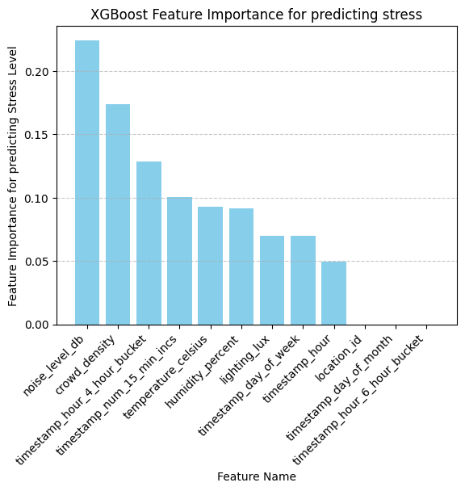

```python
# Note: I am purposefully not putting this into a function so the visualizations can be easier to customize individually later
fig4, ax = plt.subplots()

ax.bar(importances_df_3['Feature'], importances_df_3['Importance'], color='skyblue')
ax.set_title('XGBoost Feature Importance for predicting stress')
ax.set_xlabel('Feature Name')
ax.set_ylabel('Feature Importance for predicting Stress Level')
ax.grid(axis='y', linestyle='--', alpha=0.7)
plt.xticks(rotation=45, ha='right')
plt.show()
```

In any case, the top features using XGBoost feature importance are also the most correlated features. Thus when showing the biggest correlations in the web app, I will just stick with the correlation coefficients for simplicity

### Future work

To further analyze feature importance, could make visualization of SHAP values Ref: https://shap.readthedocs.io/en/latest/

## Daily Pattern Analysis

### Motivation

Stress patterns may vary significantly from day to day due to:

- **Academic schedules**: Different class loads on different days
- **Social factors**: Weekend vs. weekday patterns
- **Environmental changes**: Weather, events, or seasonal factors
- **Psychological factors**: Weekly stress cycles or anticipation effects

### Methodology

We analyze each day separately to identify:

1. **Daily correlation patterns**: How feature-stress relationships vary by day in terms of correlations and feature importances
2. **Consistency vs. variability**: Whether patterns are stable or change significantly

### Expected Insights

This analysis can reveal:

- **High-stress days**: Days when environmental factors have stronger effects
- **Intervention opportunities**: Days when specific factors are most influential
- **Resilience patterns**: Days when students are less sensitive to environmental factors

```python
# for daily analysis, the day of week has a single value so it will be dropped from importance analysis
data_by_day = data.drop('timestamp_day_of_week', axis=1).set_index('timestamp_day_of_month')
```

```python
# Analyze each day separately to identify daily stress patterns
# Calculate correlations and feature importance for each day
correlations_by_day = pd.DataFrame()
feat_importances_by_day = pd.DataFrame()

correlation_rankings_by_day = pd.DataFrame()
feat_importance_rankings_by_day = pd.DataFrame()

for _day_value in set(data_by_day.index):
    daily_data = data_by_day.loc[_day_value].reset_index().drop('timestamp_day_of_month', axis=1)

    corr_results_by_day = get_features_most_corr_with_stress(daily_data)

    correlations_by_day[f'day_{_day_value}'] = corr_results_by_day.set_index('Feature')['Correlation']

    correlation_rankings_by_day[f'day_{_day_value}'] = corr_results_by_day.set_index('Correlation_Ranking')['Feature']

    importances_df = train_and_get_importances(daily_data.drop('stress_level', axis=1), daily_data['stress_level'])
    feat_importances_by_day[f'day_{_day_value}'] = importances_df.set_index('Feature')['Importance']
    feat_importance_rankings_by_day[f'day_{_day_value}'] = importances_df.set_index('Feature')['Importance_Ranking']
```

```python
correlations_by_day
```

| Feature | day_1 | day_2 | day_3 | day_4 | day_5 | day_6 | day_7 | day_8 | day_9 | day_10 | day_11 |
| --- | --- | --- | --- | --- | --- | --- | --- | --- | --- | --- | --- |
| mental_health_status | 0.780640 | 0.845603 | 0.847481 | 0.795301 | 0.871984 | 0.828520 | 0.841621 | 0.853056 | 0.783348 | 0.822907 | 0.808673 |
| sleep_hours | -0.460999 | -0.454440 | -0.449113 | -0.430920 | -0.423352 | -0.479741 | -0.407993 | -0.372128 | -0.498212 | -0.467763 | -0.452229 |
| air_quality_index | 0.435739 | 0.449089 | 0.650669 | 0.605602 | 0.562414 | 0.579312 | 0.591022 | 0.551594 | 0.560127 | 0.548979 | 0.572253 |
| mood_score | -0.384726 | -0.326542 | -0.553342 | -0.404156 | -0.333828 | -0.568563 | -0.350419 | -0.309434 | -0.395287 | -0.424415 | -0.476545 |
| humidity_percent | -0.260417 | -0.153665 | 0.093932 | 0.060031 | -0.058239 | -0.178339 | -0.025124 | 0.071380 | 0.062868 | -0.036833 | 0.238339 |
| location_id | -0.211368 | -0.004677 | 0.042796 | -0.107871 | 0.080315 | -0.088421 | 0.170108 | 0.181562 | -0.141159 | 0.072897 | 0.111570 |
| timestamp_num_15_min_incs | 0.192871 | -0.091442 | -0.151408 | -0.011630 | 0.103384 | 0.071432 | 0.139798 | 0.087154 | 0.141615 | -0.069554 | 0.271371 |
| timestamp_hour | 0.188585 | -0.090794 | -0.153484 | -0.016562 | 0.095946 | 0.074527 | 0.144531 | 0.089884 | 0.143560 | -0.069355 | 0.275591 |
| timestamp_hour_6_hour_bucket | 0.162836 | -0.165783 | -0.162293 | -0.019361 | 0.118090 | 0.110304 | 0.129963 | 0.056458 | 0.146750 | -0.096791 | 0.234146 |
| noise_level_db | 0.160894 | 0.258393 | 0.112317 | 0.087825 | 0.307722 | 0.301239 | 0.306770 | 0.302058 | 0.348562 | 0.165154 | 0.342501 |
| timestamp_hour_4_hour_bucket | 0.136433 | -0.118012 | -0.165020 | -0.030044 | 0.111615 | 0.056598 | 0.154208 | 0.097240 | 0.152052 | -0.044203 | 0.283314 |
| lighting_lux | -0.098762 | -0.005618 | -0.074948 | 0.010609 | 0.053584 | 0.037508 | 0.047000 | 0.092720 | 0.097272 | 0.020390 | -0.142100 |
| temperature_celsius | -0.035014 | -0.118029 | -0.080360 | -0.061468 | -0.072719 | -0.128884 | -0.123508 | -0.139010 | 0.078762 | 0.061894 | 0.062692 |
| crowd_density | -0.022091 | 0.130957 | 0.357807 | 0.079820 | 0.183391 | 0.382242 | 0.107840 | 0.373778 | 0.336588 | 0.144301 | 0.156849 |

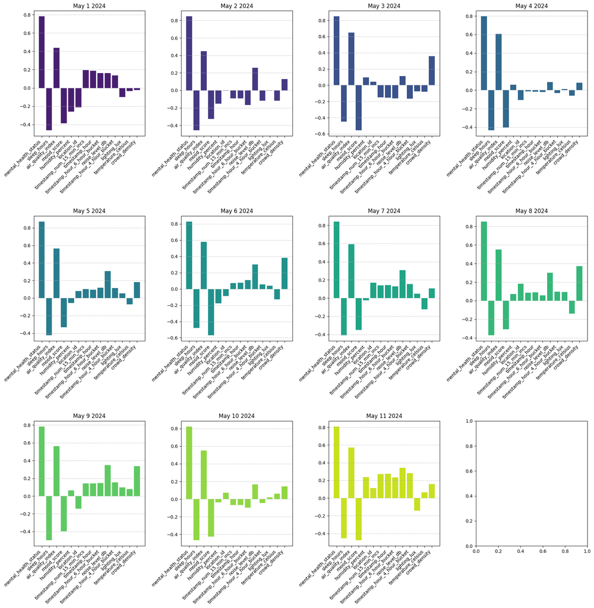

```python
fig5, axes = plt.subplots(3, 4, figsize=(18, 20))
fig.suptitle('Correlation Graphs by Day')

axes = axes.flatten()

for day_number in range(1, 12):

    ax = axes[day_number - 1]

    ax.bar(correlations_by_day.index, correlations_by_day[f'day_{day_number}'], color=plt.cm.viridis(day_number / 12.0))
    ax.set_title(f'May {day_number} 2024')
    ax.grid(axis='y', linestyle='--', alpha=0.7)
    ax.set_xticks(range(len(correlations_by_day.index))) # Ensure ticks are at correct positions
    ax.set_xticklabels(correlations_by_day.index, rotation=45, ha='right')

plt.tight_layout(rect=[0, 0.03, 1, 0.95], h_pad=3.0)
plt.show()
```

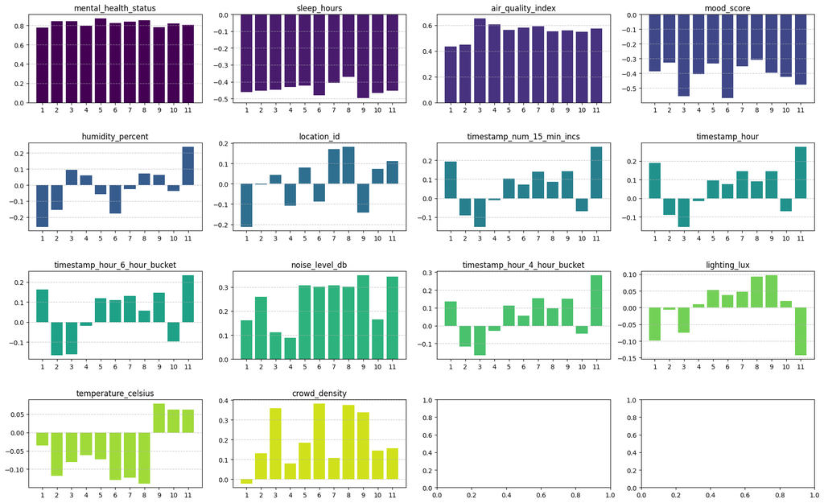

```python
# Visualize correlations changing over time for a given feature

fig6, axes = plt.subplots(4, 4, figsize=(18, 12))
fig.suptitle('Correlation Graphs by Feature')

axes = axes.flatten()

day_numbers_only = [x.split("_")[1] for x in correlations_by_day.columns]

for feat_number in range(len(correlations_by_day.index)):

    ax = axes[feat_number]

    feat_name = correlations_by_day.index[feat_number]

    ax.bar(day_numbers_only, correlations_by_day.loc[feat_name], color=plt.cm.viridis(feat_number / 14.0))
    ax.set_title(feat_name)
    ax.grid(axis='y', linestyle='--', alpha=0.7)


plt.tight_layout(rect=[0, 0.03, 1, 0.95], h_pad=3.0)
plt.show()
```

```python
correlation_rankings_by_day
```

| Correlation_Ranking | day_1 | day_2 | day_3 | day_4 | day_5 | day_6 | day_7 | day_8 | day_9 | day_10 | day_11 |
| --- | --- | --- | --- | --- | --- | --- | --- | --- | --- | --- | --- |
| 1 | mental_health_status | mental_health_status | mental_health_status | mental_health_status | mental_health_status | mental_health_status | mental_health_status | mental_health_status | mental_health_status | mental_health_status | mental_health_status |
| 2 | sleep_hours | sleep_hours | air_quality_index | air_quality_index | air_quality_index | air_quality_index | air_quality_index | air_quality_index | air_quality_index | air_quality_index | air_quality_index |
| 3 | air_quality_index | air_quality_index | mood_score | sleep_hours | sleep_hours | mood_score | sleep_hours | crowd_density | sleep_hours | sleep_hours | mood_score |
| 4 | mood_score | mood_score | sleep_hours | mood_score | mood_score | sleep_hours | mood_score | sleep_hours | mood_score | mood_score | sleep_hours |
| 5 | humidity_percent | noise_level_db | crowd_density | location_id | noise_level_db | crowd_density | noise_level_db | mood_score | noise_level_db | noise_level_db | noise_level_db |
| 6 | location_id | timestamp_hour_6_hour_bucket | timestamp_hour_4_hour_bucket | noise_level_db | crowd_density | noise_level_db | location_id | noise_level_db | crowd_density | crowd_density | timestamp_hour_4_hour_bucket |
| 7 | timestamp_num_15_min_incs | humidity_percent | timestamp_hour_6_hour_bucket | crowd_density | timestamp_hour_6_hour_bucket | humidity_percent | timestamp_hour_4_hour_bucket | location_id | timestamp_hour_4_hour_bucket | timestamp_hour_6_hour_bucket | timestamp_hour |
| 8 | timestamp_hour | crowd_density | timestamp_hour | temperature_celsius | timestamp_hour_4_hour_bucket | temperature_celsius | timestamp_hour | temperature_celsius | timestamp_hour_6_hour_bucket | location_id | timestamp_num_15_min_incs |
| 9 | timestamp_hour_6_hour_bucket | temperature_celsius | timestamp_num_15_min_incs | humidity_percent | timestamp_num_15_min_incs | timestamp_hour_6_hour_bucket | timestamp_num_15_min_incs | timestamp_hour_4_hour_bucket | timestamp_hour | timestamp_num_15_min_incs | humidity_percent |
| 10 | noise_level_db | timestamp_hour_4_hour_bucket | noise_level_db | timestamp_hour_4_hour_bucket | timestamp_hour | location_id | timestamp_hour_6_hour_bucket | lighting_lux | timestamp_num_15_min_incs | timestamp_hour | timestamp_hour_6_hour_bucket |
| 11 | timestamp_hour_4_hour_bucket | timestamp_num_15_min_incs | humidity_percent | timestamp_hour_6_hour_bucket | location_id | timestamp_hour | temperature_celsius | timestamp_hour | location_id | temperature_celsius | crowd_density |
| 12 | lighting_lux | timestamp_hour | temperature_celsius | timestamp_hour | temperature_celsius | timestamp_num_15_min_incs | crowd_density | timestamp_num_15_min_incs | lighting_lux | timestamp_hour_4_hour_bucket | lighting_lux |
| 13 | temperature_celsius | lighting_lux | lighting_lux | timestamp_num_15_min_incs | humidity_percent | timestamp_hour_4_hour_bucket | lighting_lux | humidity_percent | temperature_celsius | humidity_percent | location_id |
| 14 | crowd_density | location_id | location_id | lighting_lux | lighting_lux | lighting_lux | humidity_percent | timestamp_hour_6_hour_bucket | humidity_percent | lighting_lux | temperature_celsius |

```python
feat_importances_by_day
```

| Feature | day_1 | day_2 | day_3 | day_4 | day_5 | day_6 | day_7 | day_8 | day_9 | day_10 | day_11 |
| --- | --- | --- | --- | --- | --- | --- | --- | --- | --- | --- | --- |
| mental_health_status | 0.445310 | 0.383140 | 0.459901 | 0.506813 | 0.608067 | 0.412782 | 0.426296 | 0.456918 | 0.472260 | 0.422139 | 0.452363 |
| sleep_hours | 0.102196 | 0.071281 | 0.045468 | 0.044173 | 0.038835 | 0.056190 | 0.048070 | 0.053339 | 0.061329 | 0.178427 | 0.037629 |
| mood_score | 0.067461 | 0.076993 | 0.096713 | 0.062278 | 0.054190 | 0.078943 | 0.045528 | 0.044074 | 0.029652 | 0.088237 | 0.147616 |
| crowd_density | 0.065838 | 0.022830 | 0.094401 | 0.044132 | 0.037861 | 0.073776 | 0.017510 | 0.039127 | 0.172306 | 0.017532 | 0.027379 |
| temperature_celsius | 0.056089 | 0.039508 | 0.012910 | 0.042302 | 0.017637 | 0.018321 | 0.021907 | 0.020882 | 0.040869 | 0.031569 | 0.030064 |
| humidity_percent | 0.053225 | 0.090714 | 0.038676 | 0.020150 | 0.018592 | 0.041230 | 0.021563 | 0.016052 | 0.017212 | 0.020610 | 0.018849 |
| air_quality_index | 0.044906 | 0.141413 | 0.099708 | 0.186614 | 0.119422 | 0.157683 | 0.142594 | 0.136358 | 0.094081 | 0.116920 | 0.078427 |
| noise_level_db | 0.040522 | 0.056612 | 0.025663 | 0.018085 | 0.042917 | 0.061648 | 0.091817 | 0.130264 | 0.033379 | 0.046250 | 0.037113 |
| location_id | 0.036630 | 0.009130 | 0.020435 | 0.000000 | 0.000000 | 0.035062 | 0.038285 | 0.000000 | 0.033759 | 0.017040 | 0.019373 |
| timestamp_hour | 0.033025 | 0.000000 | 0.056238 | 0.022365 | 0.000000 | 0.000000 | 0.035343 | 0.041088 | 0.000000 | 0.013907 | 0.000000 |
| timestamp_num_15_min_incs | 0.028850 | 0.062680 | 0.015858 | 0.021402 | 0.012277 | 0.027250 | 0.017846 | 0.013242 | 0.021521 | 0.000000 | 0.127704 |
| lighting_lux | 0.025947 | 0.045699 | 0.017488 | 0.014999 | 0.024014 | 0.037117 | 0.028319 | 0.025871 | 0.023631 | 0.047368 | 0.023484 |
| timestamp_hour_4_hour_bucket | 0.000000 | 0.000000 | 0.016541 | 0.016688 | 0.026189 | 0.000000 | 0.025467 | 0.022783 | 0.000000 | 0.000000 | 0.000000 |
| timestamp_hour_6_hour_bucket | 0.000000 | 0.000000 | 0.000000 | 0.000000 | 0.000000 | 0.000000 | 0.039456 | 0.000000 | 0.000000 | 0.000000 | 0.000000 |

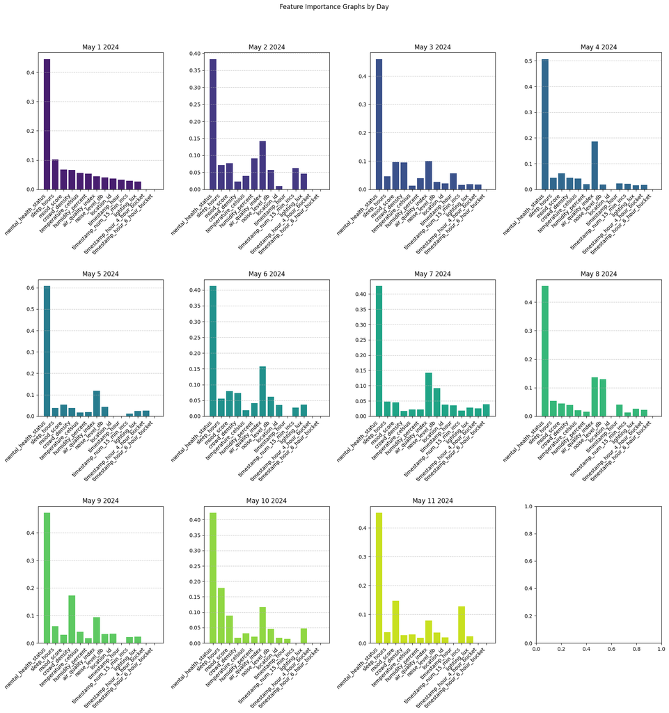

```python
fig6, axes = plt.subplots(3, 4, figsize=(18, 20))
fig6.suptitle('Feature Importance Graphs by Day')

axes = axes.flatten()

for day_number in range(1, 12):

    ax = axes[day_number - 1]

    ax.bar(feat_importances_by_day.index, feat_importances_by_day[f'day_{day_number}'], color=plt.cm.viridis(day_number / 12.0))
    ax.set_title(f'May {day_number} 2024')
    ax.grid(axis='y', linestyle='--', alpha=0.7)
    ax.set_xticks(range(len(feat_importances_by_day.index))) # Ensure ticks are at correct positions
    ax.set_xticklabels(feat_importances_by_day.index, rotation=45, ha='right')

plt.tight_layout(rect=[0, 0.03, 1, 0.95], h_pad=3.0)
plt.show()
```

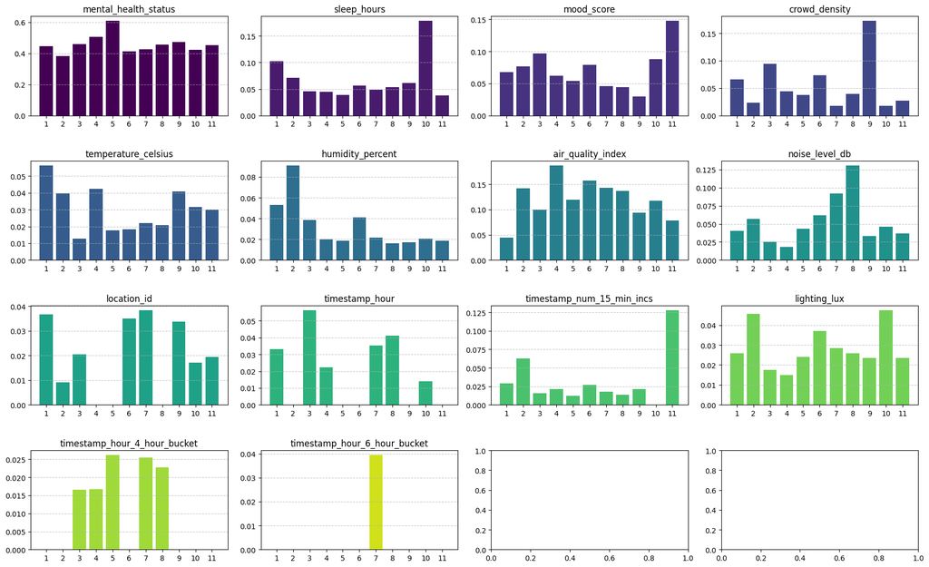

```python
# Visualize feature importances changing over time for a given feature

fig6, axes = plt.subplots(4, 4, figsize=(18, 12))
fig.suptitle('Feature Importance Graphs by Feature')

axes = axes.flatten()

day_numbers_only = [x.split("_")[1] for x in feat_importances_by_day.columns]

for feat_number in range(len(feat_importances_by_day.index)):

    ax = axes[feat_number]

    feat_name = feat_importances_by_day.index[feat_number]

    ax.bar(day_numbers_only, feat_importances_by_day.loc[feat_name], color=plt.cm.viridis(feat_number / 14.0))
    ax.set_title(feat_name)
    ax.grid(axis='y', linestyle='--', alpha=0.7)


plt.tight_layout(rect=[0, 0.03, 1, 0.95], h_pad=3.0)
plt.show()
```

```python
feat_importance_rankings_by_day
```

| Feature | day_1 | day_2 | day_3 | day_4 | day_5 | day_6 | day_7 | day_8 | day_9 | day_10 | day_11 |
| --- | --- | --- | --- | --- | --- | --- | --- | --- | --- | --- | --- |
| mental_health_status | 1 | 1 | 1 | 1 | 1 | 1 | 1 | 1 | 1 | 1 | 1 |
| sleep_hours | 2 | 5 | 6 | 4 | 5 | 6 | 4 | 4 | 4 | 2 | 5 |
| mood_score | 3 | 4 | 3 | 3 | 3 | 3 | 5 | 5 | 8 | 4 | 2 |
| crowd_density | 4 | 10 | 4 | 5 | 6 | 4 | 14 | 7 | 2 | 9 | 8 |
| temperature_celsius | 5 | 9 | 13 | 6 | 10 | 11 | 11 | 10 | 5 | 7 | 7 |
| humidity_percent | 6 | 3 | 7 | 9 | 9 | 7 | 12 | 11 | 11 | 8 | 11 |
| air_quality_index | 7 | 2 | 2 | 2 | 2 | 2 | 2 | 2 | 3 | 3 | 4 |
| noise_level_db | 8 | 7 | 8 | 10 | 4 | 5 | 3 | 3 | 7 | 6 | 6 |
| location_id | 9 | 11 | 9 | 13 | 12 | 9 | 7 | 13 | 6 | 10 | 10 |
| timestamp_hour | 10 | 12 | 5 | 7 | 13 | 12 | 8 | 6 | 12 | 11 | 12 |
| timestamp_num_15_min_incs | 11 | 6 | 12 | 8 | 11 | 10 | 13 | 12 | 10 | 14 | 3 |
| lighting_lux | 12 | 8 | 10 | 12 | 8 | 8 | 9 | 8 | 9 | 5 | 9 |
| timestamp_hour_4_hour_bucket | 13 | 13 | 11 | 11 | 7 | 13 | 10 | 9 | 13 | 12 | 13 |
| timestamp_hour_6_hour_bucket | 14 | 14 | 14 | 14 | 14 | 14 | 6 | 14 | 14 | 13 | 14 |

## Key Findings and Implications

### Primary Insights

1. **Mental Health Status Dominance**: Mental health status is the strongest predictor of stress levels, indicating the importance of mental health screening and support services.
2. **Environmental Factors Matter**: Even after controlling for mental health status, environmental factors like air quality, sleep, and mood remain important predictors.
3. **Temporal Patterns**: Time-based factors show varying importance across different days, suggesting that intervention timing matters.

### Recommendations for Universities

1. **Mental Health Services**: Prioritize mental health screening and support programs
2. **Environmental Improvements**: Focus on air quality, noise reduction, and lighting optimization
3. **Sleep Promotion**: Implement programs to encourage healthy sleep habits
4. **Temporal Interventions**: Consider timing of support services based on daily stress patterns

### Future Research Directions

1. **Longitudinal Studies**: Track students over longer periods to understand stress evolution
2. **Intervention Studies**: Test the effectiveness of environmental modifications
3. **Personalized Approaches**: Develop individual stress prediction models
4. **Real-time Monitoring**: Implement real-time stress monitoring and intervention systems

### Technical Notes

- Feature importance and correlation rankings provide actionable insights for intervention design
- Daily analysis reveals temporal patterns that could inform scheduling decisions
- The iterative approach helps understand factor interactions and relative importance